# GR4058 Data Mining Assignment #2

Nathan Taylor

Tuesday, October 10, 2017

# 1. Matrix Algebra

**Prompt: Question 4 on pages 301 – 302 of Moore and Siegel. You can use R.**

```r
A <- matrix(c(5, 6, 1, 2, 2, 3),
            nrow = 2,
            ncol = 3)
A
```

```
##      [,1] [,2] [,3]
## [1,]    5    1    2
## [2,]    6    2    3
```

```r
B <- matrix(c(3, -2, 4, -3, 5, 6),
            nrow = 2,
            ncol = 3)
B
```

```
##      [,1] [,2] [,3]
## [1,]    3    4    5
## [2,]   -2   -3    6
```

```r
C <- matrix(c(1, -5, -3, 2, 3, 1),
            nrow = 3,
            ncol = 2)
C
```

```
##      [,1] [,2]
## [1,]    1    2
## [2,]   -5    3
## [3,]   -3    1
```

```r
D <- matrix(c(2, 4, 1, 3),
            nrow = 2,
            ncol = 2)
D
```

```
##      [,1] [,2]
## [1,]    2    1
## [2,]    4    3
```

```r
# 4.a  --  Cannot add two matrices that do not have the same size/
# dimensions, see error below
A + C
```

```
## Error in A + C: non-conformable arrays
```

```r
# 4.b
A - B
```

```
##      [,1] [,2] [,3]
## [1,]    2   -3   -3
## [2,]    8    5   -3
```

```r
# 4.c
A + (5 * B)
```

```
##      [,1] [,2] [,3]
## [1,]   20   21   27
## [2,]   -4  -13   33
```

```r
# 4.d
3 * A
```

```
##      [,1] [,2] [,3]
## [1,]   15    3    6
## [2,]   18    6    9
```

```r
# 4.e
(2 * B) - (5 * A)
```

```
##      [,1] [,2] [,3]
## [1,]  -19    3    0
## [2,]  -34  -16   -3
```

```r
# 4.f
t(B) - C
```

```
##      [,1] [,2]
## [1,]    2   -4
## [2,]    9   -6
## [3,]    8    5
```

```r
# 4.g   --  Cannot multiply two matrices that do not have the same size/
# dimensions, see error below
B %*% A
```

```
## Error in B %*% A: non-conformable arguments
```

```r
# 4.h
D %*% A
```

```
##      [,1] [,2] [,3]
## [1,]   16    4    7
## [2,]   38   10   17
```

```r
# 4.i --  Cannot multiply two matrices that do not have the same size
# dimensions, see error below
A %*% D
```

```
## Error in A %*% D: non-conformable arguments
```

```r
# 4.j
C %*% D
```

```
##      [,1] [,2]
## [1,]   10    7
## [2,]    2    4
## [3,]   -2    0
```

```r
# 4.k
B %*% C
```

```
##      [,1] [,2]
## [1,]  -32   23
## [2,]   -5   -7
```

```r
# 4.l
C %*% B
```

```
##      [,1] [,2] [,3]
## [1,]   -1   -2   17
## [2,]  -21  -29   -7
## [3,]  -11  -15   -9
```

# 2. Inverse of Matrices

**Prompt: Is it true that…**

$$(\mathbf{W} + \mathbf{xy}^{\top})^{-1} = \mathbf{W}^{-1} - \frac{\mathbf{W}^{-1}\mathbf{xy}^{\top}\mathbf{W}^{-1}}{1 + \mathbf{y}^{\top}\mathbf{W}^{-1}\mathbf{x}}$$

**… presuming that all matrices and vectors are conformable for multiplication and that W^-1 exists? Show your work as to why or why not.**

$$(\mathbf{W} + \mathbf{xy}^{\top})^{-1} = \mathbf{W}^{-1} - \frac{\mathbf{W}^{-1}\mathbf{xy}^{\top}\mathbf{W}^{-1}}{1 + \mathbf{y}^{\top}\mathbf{W}^{-1}\mathbf{x}}$$

$$\frac{1}{\mathbf{W} + \mathbf{xy}^{\top}} = \frac{1}{\mathbf{W} - \frac{\mathbf{W}^{-1}\mathbf{xy}^{\top}\mathbf{W}^{-1}}{1 + \mathbf{xy}^{\top}\mathbf{W}^{-1}}$$

$$\frac{1}{\mathbf{W} + \mathbf{xy}^{\top}} = \frac{(1 + \mathbf{W}^{-1}\mathbf{xy}^{\top}) - \mathbf{W}(\mathbf{W}^{-1}\mathbf{xy}^{\top}\mathbf{W}^{-1})}{\mathbf{W}(1 + \mathbf{xy}^{\top}\mathbf{W}^{-1})}$$

$$\frac{1}{\mathbf{W} + \mathbf{xy}^{\top}} = \frac{1 + \mathbf{W}^{-1}\mathbf{xy}^{\top} - \mathbf{xy}^{\top}\mathbf{W}^{-1}}{\mathbf{W} +I\mathbf{xy}^{\top}}$$

$$\frac{1}{\mathbf{W} + \mathbf{xy}^{\top}} = \frac{1}{\mathbf{W} + \mathbf{xy}^{\top}}$$

It is true.

# 3. Apartment Prices

**Prompt: Use the functions in the ggplot2 package to create a scatterplot between totalprice and one other numeric variable (possibly with transformations, rescalings, etc.) using relevant discrete variables to distinguish points by size, color, and / or symbol that is explained in a legend. What do you discover by visualizing the data this way?**

I wanted to examine the relationship between the area of an apartment and the total price for the apartment in the data frame `apts`. Using ggplot2, I graphed `totalprice` as a function of `area`.

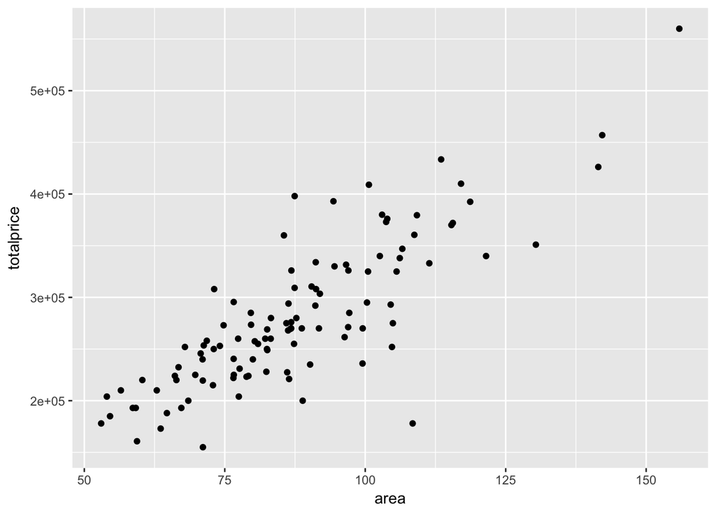

```r
apts <- readRDS(gzcon(url('https://courseworks.columbia.edu/x/pJdP39')))
library(ggplot2)
plot1 <- ggplot(apts) +
  geom_point(mapping = aes(x = area, y = totalprice))
plot1
```

After a quick glance, it appears that there is a relationship between the square meterage of an apartment and its overall price. With 109 observations, there doesn’t appear to be any need to rescale the range on either the x- or y-axis. However, I was curious if the number of rooms an apartment has would influence their distribution on this scatter plot, so I included that variable below.

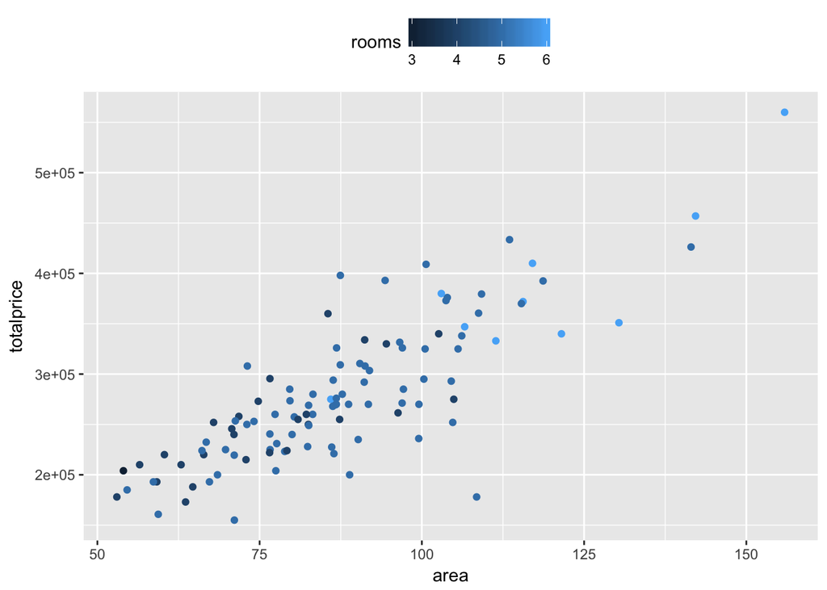

```r
plot2 <- ggplot(apts) +
  geom_point(mapping = aes(x = area, y = totalprice, color = rooms)) +
  theme(legend.position = "top")
plot2
```

This scatter plot reinforces the fact that apartments with more area and a higher price are more likely to have 5 or 6 rooms in comparison to those with less space and priced lower. This finding makes sense since apartments with more floor area would likely have more rooms as well. The color gradient on the map appear to do a sufficient enough job discerning the number of rooms within the data frame. Below is an attempt to fit a smooth line on the relationship.

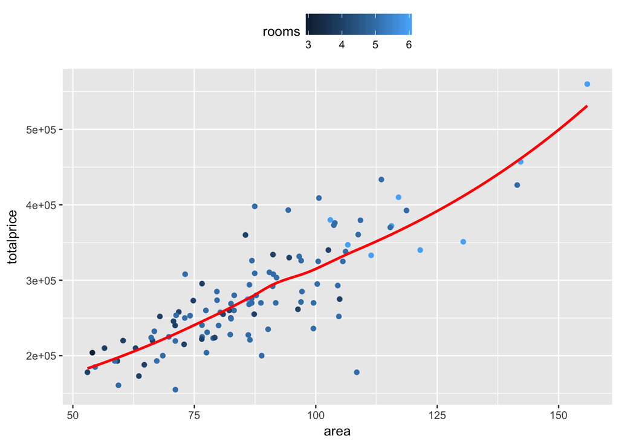

```r
plot3 <- ggplot(apts, mapping = aes(x = area, y = totalprice, color = rooms)) +
  geom_point() +
  geom_smooth(se = FALSE, col = "red") +
  theme(legend.position = "top")
plot3
```

It appears almost linear, but has at least one noticeable bumps and a curve to it.

# 4. Making Plots

**Prompt: Look at help(chickwts) for information on the chickwts data.frame. Produce a box-and-whiskers plot of weight for each of the six types of feed using the ggplot2 package. Interpret your plots.**

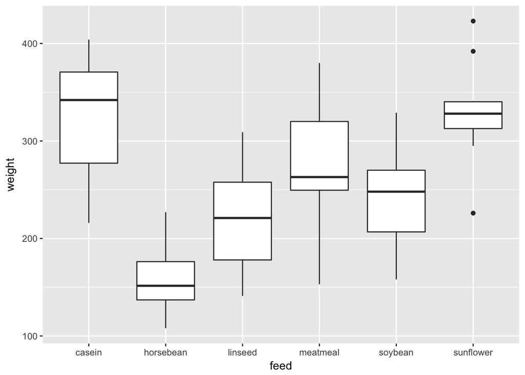

```r
help(chickwts)
plot4 <- ggplot(chickwts) +
  geom_boxplot(mapping = aes(x = feed, y = weight))
plot4
```

# 5. Histograms

**Prompt: Create a separate histogram using the functions in the ggplot2 package for each of the following four variables in the Cars93 data.frame: Min.Price, Max.Price, Weight, Length. Then, create a histogram of the Price variable conditioning (stratifying) on each level of DriveTrain, which indicates which axle(s) of the car turn the wheels. What would you conclude from these plots?**

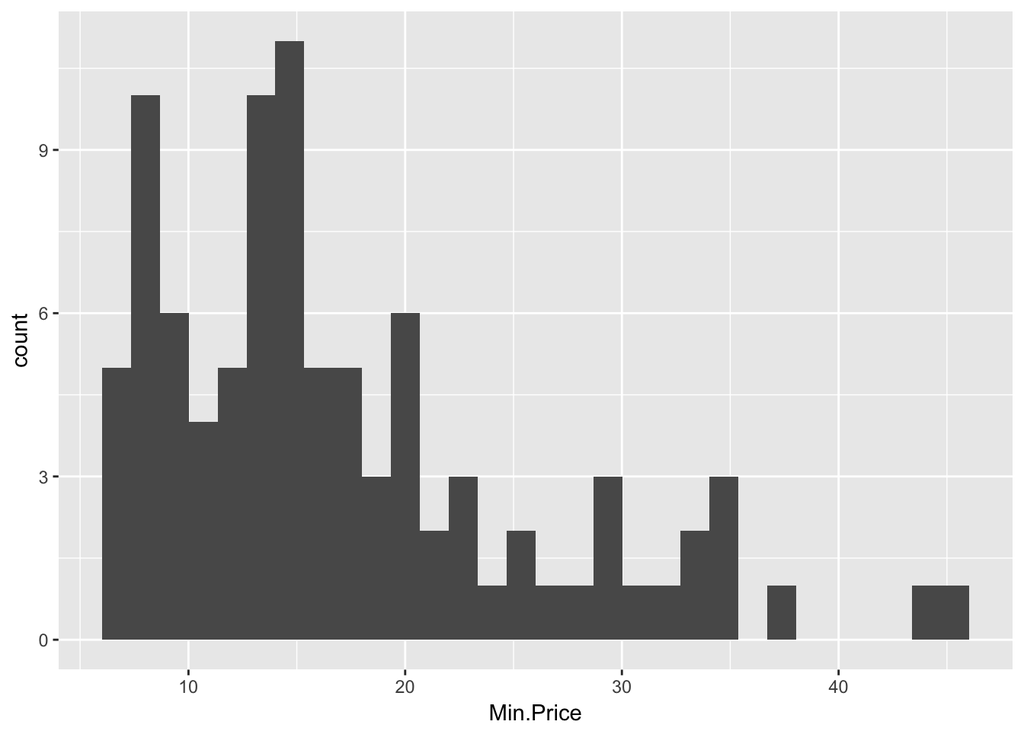

```r
library(MASS)
# help(Cars93)

car1 <- ggplot(Cars93) + geom_histogram(mapping = aes(Min.Price))
car1
```

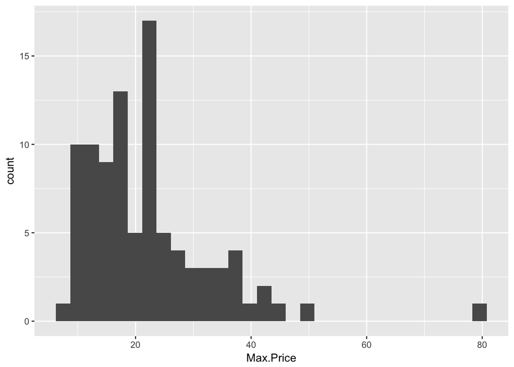

```r
car2 <- ggplot(Cars93) + geom_histogram(mapping = aes(Max.Price))
car2
```

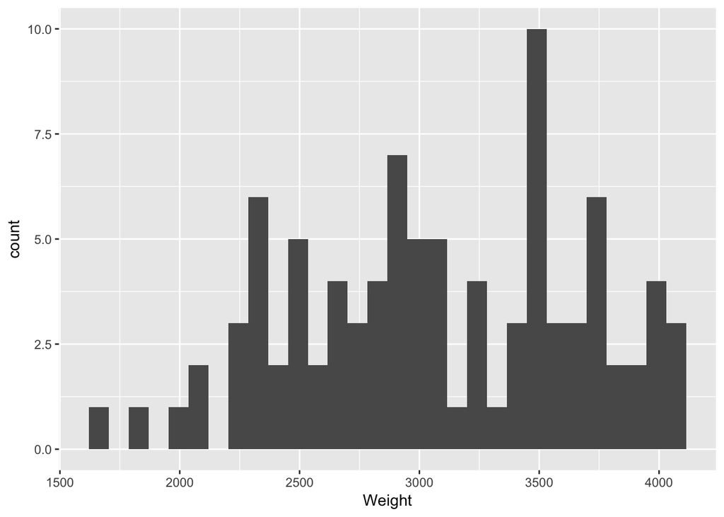

```r
car3 <- ggplot(Cars93) + geom_histogram(mapping = aes(Weight))
car3
```

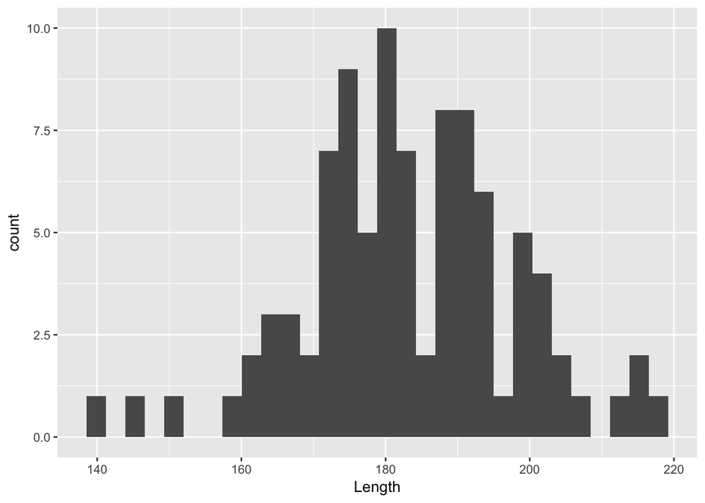

```r
car4 <- ggplot(Cars93) + geom_histogram(mapping = aes(Length))
car4
```

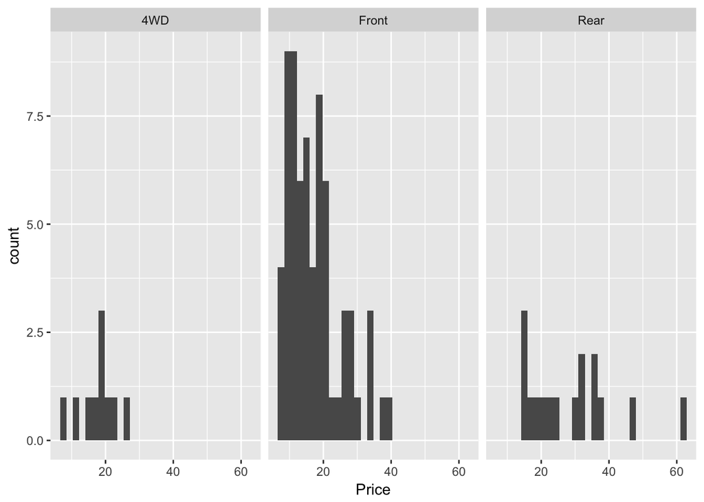

```r
car5 <- ggplot(Cars93) +
  geom_histogram(mapping = aes(Price)) +
  facet_wrap(~ DriveTrain)
car5
```

After examining the histograms, it appears that both `Min.Prince` and `Max.Price` share a positive distribution. The key difference between the two is that `Max.Price` is shifted up the on the price scale more than `Min.Price`.

Finally, the stratified histogram illustrates that the vast number of cars being sold have front axis drive trains, with few having 4-wheel drive or rear wheel driving. The car with the highest midrange price is rear wheel drive car, however.